# Practical Machine Learning Assignment

Shashikat Singh Kunwar

03/09/2021

# Introduction

In this work I will be using the data obtained from volunteers who were using fitness devices during various physics activities. Based on the reading of various sensors in these wearable devices one can identify the activity those readings correspond to.

# Data download and preprocessing

This function can be used to download the training and test data. Data is downloaded only if those files are not present in the current working directory.

```r
## script to downloaded data from the URL into current working directory
download_data<-function(){
    # url of training and test data
    urltr<-"https://d396qusza40orc.cloudfront.net/predmachlearn/pml-training.csv"
    urlts<-"https://d396qusza40orc.cloudfront.net/predmachlearn/pml-testing.csv"

    # downloading file only if it is not present in current working directory
    if(!file.exists("pml-training.csv")){
        download.file(urltr,destfile = "./pml-training.csv",method="curl")
    }

    if(!file.exists("pml-testing.csv")){
        download.file(urlts,destfile = "./pml-testing.csv",method = "curl")
    }}
```

Once the data is downloaded this function allows it to be loaded into the working environment. The response variable in the train_data needs to be converted into factor variable for the classification problem. I then extract all the predictors that have data corresponding to accelerometer using the grep command. For this part I ignore the columns that have NA values. The function returns train_data for the accelerometer along with the labels(response).

```r
## Once the data is downloaded script will load the data in the working environment
## The response column (classe in this case) is converted into factor variable for
## the classification task
## The column corresponding to accelerometer data are filtered using grep
## Columns with NA are stored in a list (listna)
## we can generate two sets of data one without NA ans one with NA (na_include=0/1).

load_traindata<-function(na_include=0){
    # loading training data
    train_data<-read.csv("pml-training.csv")

    # names of all the predictor variables
    all_predictors<-names(train_data)

    # converting classe column into factor variable
    train_data$classe<-as.factor(train_data$classe)

    # name of columns that contains data for accelerometer
    accel_predictors<-all_predictors[grep("*accel*",all_predictors)]

    # list to store column name with NA
    listna<-c()
    for (j in seq(1:20)){
        # check if nas exist for a particular column
        # if yes store the column name in listna
        if (sum(is.na(train_data[,accel_predictors[j]]))){
        listna<-c(listna,j)}}

    if(na_include==0){
        # list of variable that don't have NA.
        accel_nona_predictors<-accel_predictors[-listna]
        data_nona_columns<-c(accel_nona_predictors,"classe")

        # return only finite data for accelerometer and labels
        train_data[,data_nona_columns]
        }
    else{
        # list of variables that have NA.
        data_all_columns<-c(accel_predictors,"classe")

        # return the accelerometer data  along with the labels
        train_data[,data_all_columns]
        }}
```

To make predictions on the test data we also need to load the test data. This function can be called from any function and it will return the test_data.

```r
# function to load the test data file
load_testdata<-function(){
    test_data<-read.csv("pml-testing.csv")
    test_data
}
```

# Model selection and training.

In this work I will be using a Gradient Boosting Algorithm(gbm). Boosted algorithm generally consists of weak learner(a decision tree with low depth). The algorithm learns from the data and improves its performance such that in multiple iterations it learns to correctly identify the data point it classified incorrectly.

A default model can perform okay but to extract the most performance out of the algorithm we need to tune the hyper parameters of the algorithm. Using a default gbm led to 75% accuracy in the test data (obtained by validating the predictions with the results of the quiz). Thus, my analysis here starts with the tuning of the parameters itself. This is done automatically and one neeeds to provide only possible range of parameters.

I already saved the model after hyper parameter tuning and k fold cross validation. The training is only performed if there is no model saved otherwise the saved model is loaded into the working environment. The steps involved in the entire classification problem can be summarised as follows.

1. Download training and test data.
2. Load training and test data.
3. Set the seed to a fixed value to allow for reproducibility.
4. Split the training data into training_data and validation_data.
5. Set the seed to a fixed value again.
6. Set the training control (how many cross validation one wants to perform and how many times).
7. Set the hyper parameter grid as well. For a gradient boosting algorithm. The depth of the estimator is one of the hyper parameter and number of boosting iterations that has to be performed is another hyper parameter. I tune only these two. However, one can tune other hyper parameter as well. Tuning more hyper parameter may take more time but if one can get correct answers using small subset of hyper parameters then one should avoid tuning more. In my case I got all correct answers on test data using these two hyper parameter only.
8. Train a model(in this case we use gradient boosting algorithm) passing the training control and hyper parameter grid.
9. Save the model.

One the model is trained we can make predictions on the validation set that we separated in the beginning. We can measure accuracy of the trained model on this hold out set. In my work I calculated confusion matrix for the validation data. The accuracy result on the validataion set is $> 0.90$.

```r
## function to perform machine learning task
classification<-function(){
    # importing library
    library(caret)

    # downloading data
    download_data()

    # loading training and test data
    train_data<-load_traindata(na_include = 0)
    test_data<-load_testdata()

    # splitting train_data into training and validation set
    set.seed(42)
    inTrain<-createDataPartition(train_data$classe,p=0.7,list=FALSE)
    training_data<-train_data[inTrain,]
    validation_data<-train_data[-inTrain,]

    # control parameters for the training and cross validation
    trcontrol<-trainControl(method = "repeatedcv",
                            number = 5,
                            repeats = 5)

    # parameter grid to fine tune our predictions
    paramgrid<-expand.grid(
        interaction.depth=c(1,5,7,9),
        n.trees=(1:20)*50,
        shrinkage=0.1,
        n.minobsinnode=20)

    set.seed(42)
    # train the model only if the model doesn't exists in the working directory
    if (!file.exists("model2.rda")){
            model2<-train(classe~.,
                data=training_data,method="gbm",
                 trControl=trcontrol,tuneGrid=paramgrid)

        # save the model for later purposes
        saveRDS(model2,file="./model2.rda")}

    # load the pre trained model in the current working environment
    model2<-readRDS("model2.rda")

    # create confusion matrix using the validation data that is kept separately
    cnfm<-confusionMatrix(predict(model2,validation_data[,1:16]),validation_data$classe)
    print("confusion matrix for the validation data")

    print(cnfm)

    # make predictions on the test data with the features used during training
    pred<-predict(model2,test_data[,names(training_data)[-17]])

    # show the predictions
    print("predictions on the test data")
    print(pred)
    }

    # call the function that perform the classification task.
    # the called function will download the data, load the data and perform the
    # training and validataion task.

    classification()
```

```
## [1] "confusion matrix for the validation data"
## Confusion Matrix and Statistics
##
##           Reference
## Prediction    A    B    C    D    E
##          A 1616   45   27   25    3
##          B   15 1039   28   11   19
##          C   23   38  955   36    3
##          D   20    6   16  884   14
##          E    0   11    0    8 1043
##
## Overall Statistics
##
##                Accuracy : 0.9409
##                  95% CI : (0.9345, 0.9468)
##     No Information Rate : 0.2845
##     P-Value [Acc > NIR] : < 2.2e-16
##
##                   Kappa : 0.9251
##
##  Mcnemar's Test P-Value : 7.406e-05
##
## Statistics by Class:
##
##                      Class: A Class: B Class: C Class: D Class: E
## Sensitivity            0.9654   0.9122   0.9308   0.9170   0.9640
## Specificity            0.9763   0.9846   0.9794   0.9886   0.9960
## Pos Pred Value         0.9417   0.9344   0.9052   0.9404   0.9821
## Neg Pred Value         0.9861   0.9790   0.9853   0.9838   0.9919
## Prevalence             0.2845   0.1935   0.1743   0.1638   0.1839
## Detection Rate         0.2746   0.1766   0.1623   0.1502   0.1772
## Detection Prevalence   0.2916   0.1890   0.1793   0.1597   0.1805
## Balanced Accuracy      0.9708   0.9484   0.9551   0.9528   0.9800
## [1] "predictions on the test data"
##  [1] B A B A A E D B A A B C B A E E A B B B
## Levels: A B C D E
```

## Model accuracy

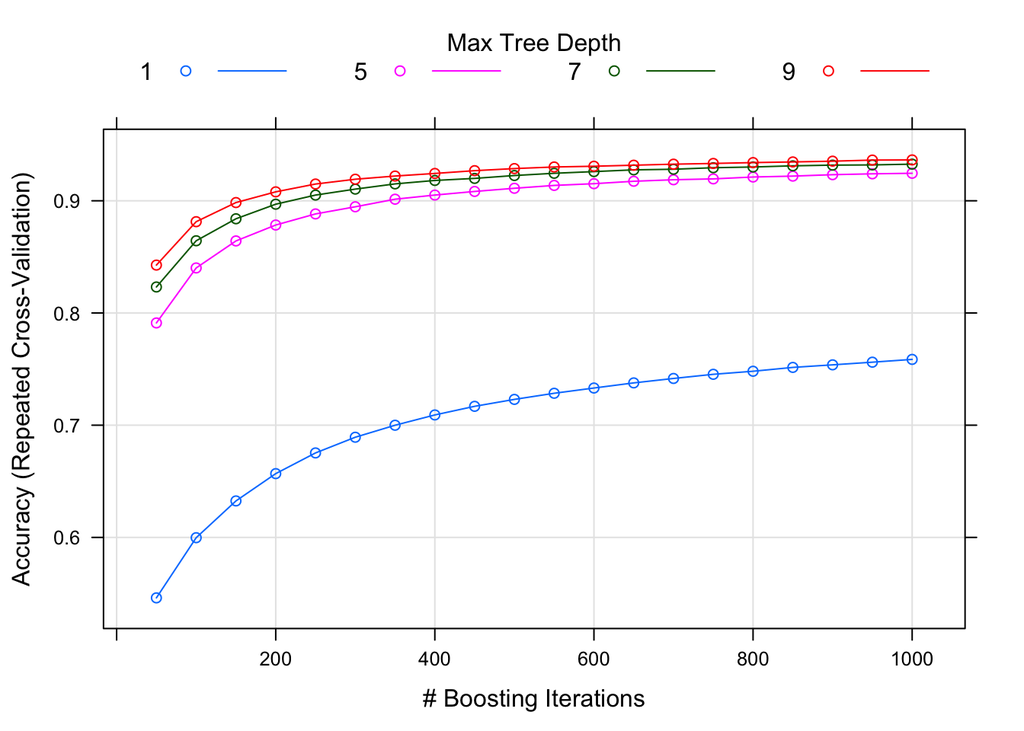

Accuracy as a function of boosting steps for different values of tree depths

```r
    library(caret)

    ## plotting model parameters
    model2<-readRDS("model2.rda")

    ## accuracy as a function of boosting cycles for different values of tree depths.
    plot(model2)
```

The boosting method also gives an estimate of the feature importance. The plot for the feature importance is shown below.

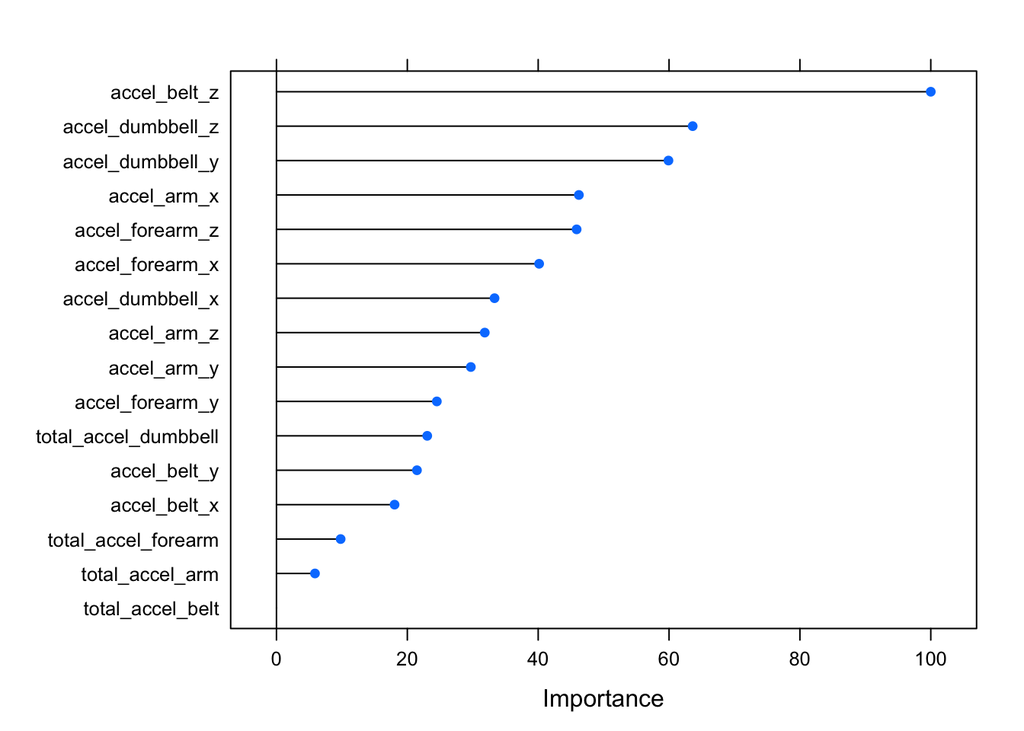

Feature importance for the gradient boosting

```r
    feature_importance<-varImp(model2)
    plot(feature_importance)
```

The plot clearly tells the accelerometer data (along z direction) in the belt is really important in the making the prediction about the activity.

# Conclusion

A trained boosted model in this case can predict the activity based on the accelerometer data.